# Análise descritiva nos dados do transporte público de Curitiba-PR - dados agrupados: terça-quinta

José Ivan Silva da Cruz Júnior

```r
library(tidyverse)
library(geosphere)
library(dplyr)
options(scipen = 999)
```

```r
grouped_result <- read_csv("/local/juninho/aggregate_output/output/result.csv", col_types = list(
    date = col_date(format = ""),
    week_day = col_double(),
    route = col_character(),
    start_hour = col_double(),
    end_hour = col_double(),
    quantity_trips = col_double(),
    duration_median = col_double(),
    dist_median = col_double()
  )
)

grouped_result <- grouped_result %>% filter(week_day == 3 | week_day == 4 | week_day == 5)
```

Análise para os dias de terça-feira até quinta-feira.

1. Há uma relação entre a distância das viagens e a tempo delas?

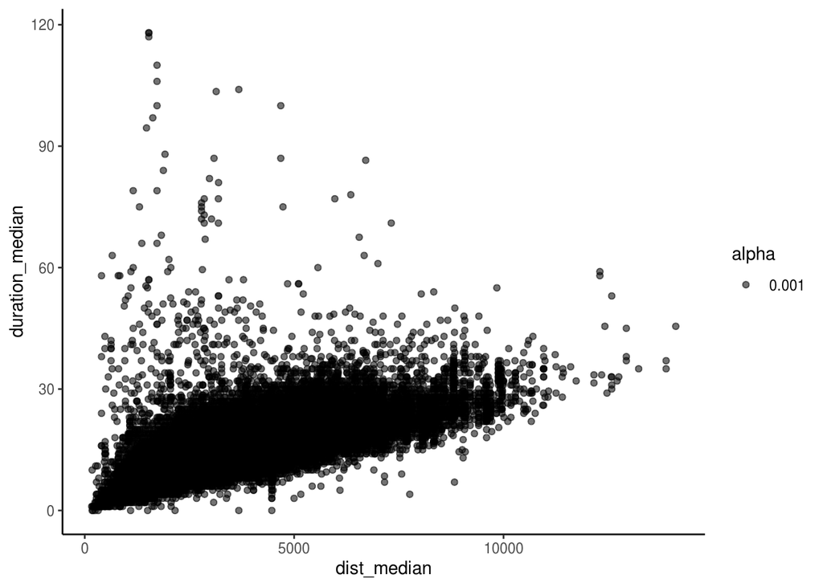

```r
grouped_result %>%
  ggplot(aes(x = dist_median, y = duration_median, alpha = .001)) %>%
  + geom_point() + theme_classic()
```

2. Quais as rotas que, na mediana, percorrem uma maior distância?

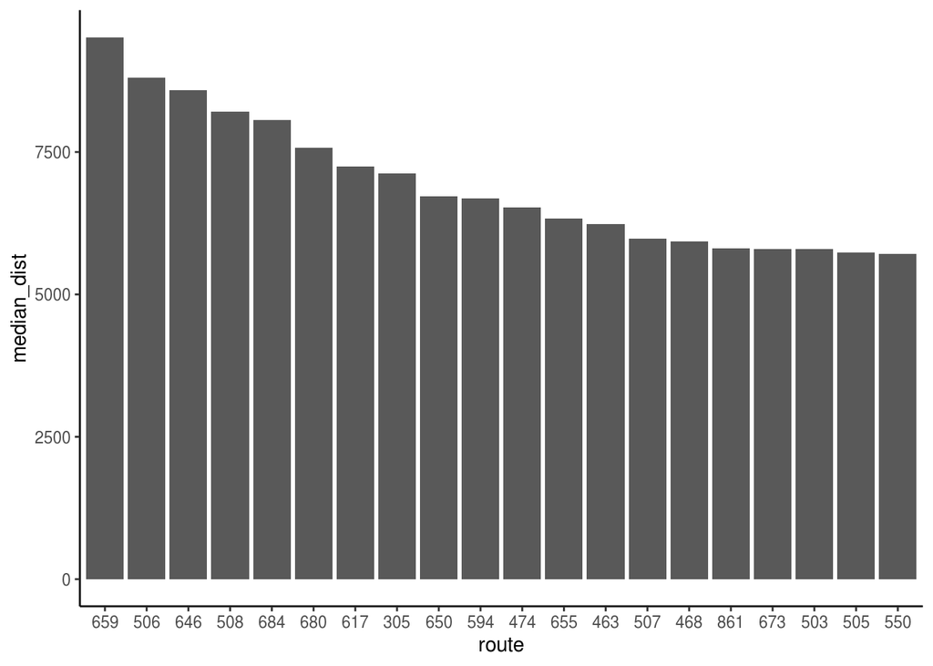

```r
grouped_result %>%
  group_by(route) %>%
  summarise(median_dist = median(dist_median)) %>%
  top_n(20) %>%
  ggplot(aes(x = reorder(route, -median_dist), y = median_dist)) + labs(x = "route") + geom_col() + theme_classic()
```

3. Quais as rotas que, na mediana, percorrem uma menor distância?

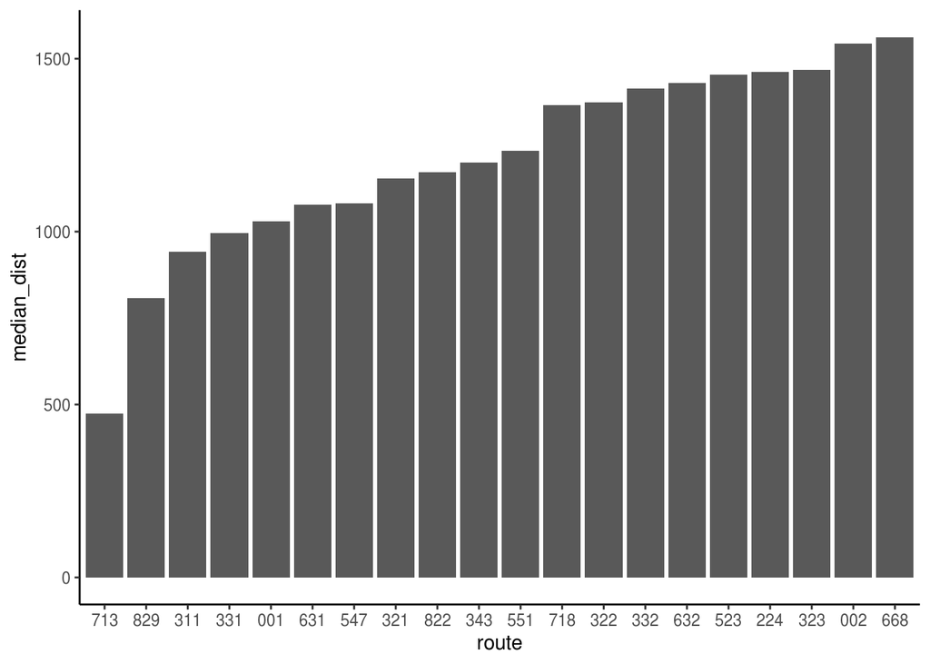

```r
grouped_result %>%
  group_by(route) %>%
  summarise(median_dist = median(dist_median)) %>%
  top_n(-20) %>%
  ggplot(aes(x = reorder(route, median_dist), y = median_dist)) + labs(x = "route") + geom_col() + theme_classic()
```

4. Quais as rotas mais populares, ou seja, aquelas com mais viagens (levando em consideração o passageiro) durante todo o período?

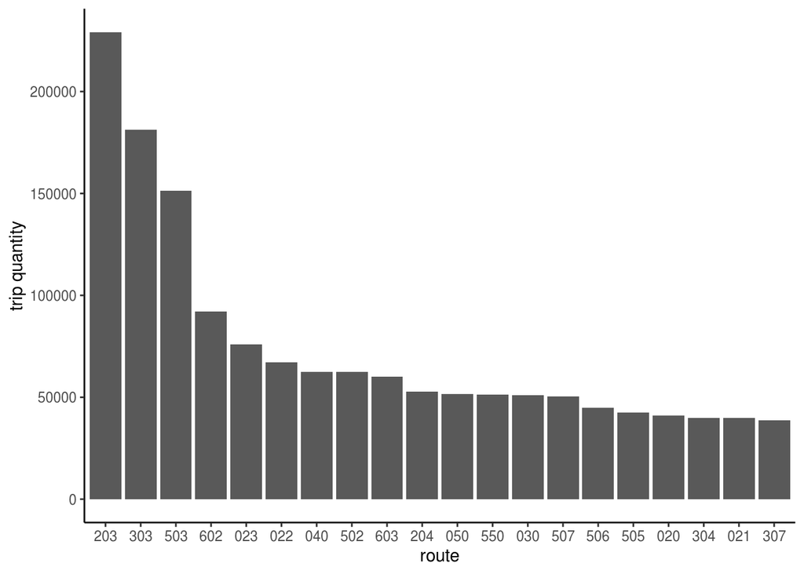

```r
grouped_result %>%
  group_by(route) %>%
  summarise(quantity = sum(quantity_trips)) %>%
  top_n(20) %>%
  ggplot(aes(x = reorder(route, -quantity), y = quantity)) + labs(x = "route", y = "trip quantity") + geom_bar(stat = "identity") + theme_classic()
```

4.1) Verificando a popularidade mês a mês, temos:

maio:

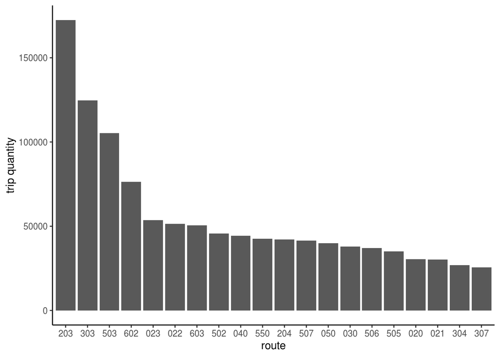

```r
grouped_result %>%
  filter(lubridate::month(lubridate::date(lubridate::ymd(date))) == 5) %>%
  group_by(route) %>%
  summarise(quantity = sum(quantity_trips)) %>%
  top_n(20) %>%
  ggplot(aes(x = reorder(route, -quantity), y = quantity)) + labs(x = "route", y = "trip quantity") + geom_bar(stat = "identity") + theme_classic()
```

junho:

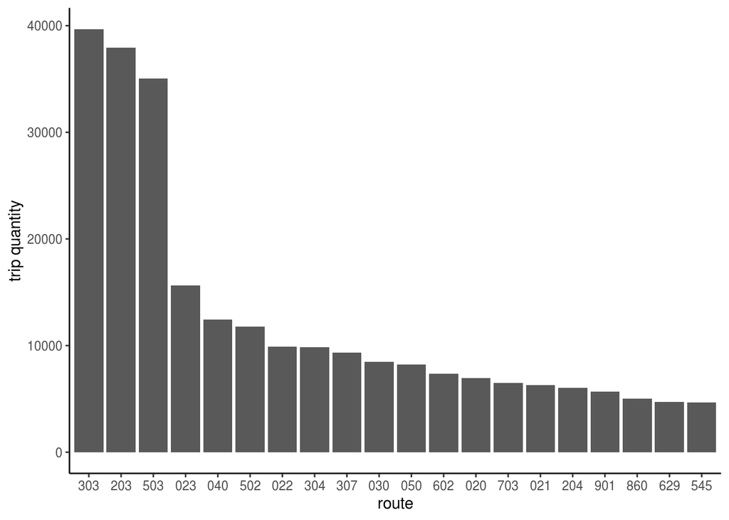

```r
grouped_result %>%
  filter(lubridate::month(lubridate::date(lubridate::ymd(date))) == 6) %>%
  group_by(route) %>%
  summarise(quantity = sum(quantity_trips)) %>%
  top_n(20) %>%
  ggplot(aes(x = reorder(route, -quantity), y = quantity)) + labs(x = "route", y = "trip quantity") + geom_bar(stat = "identity") + theme_classic()
```

Destaque: rota 602, 603, 507, 550

julho:

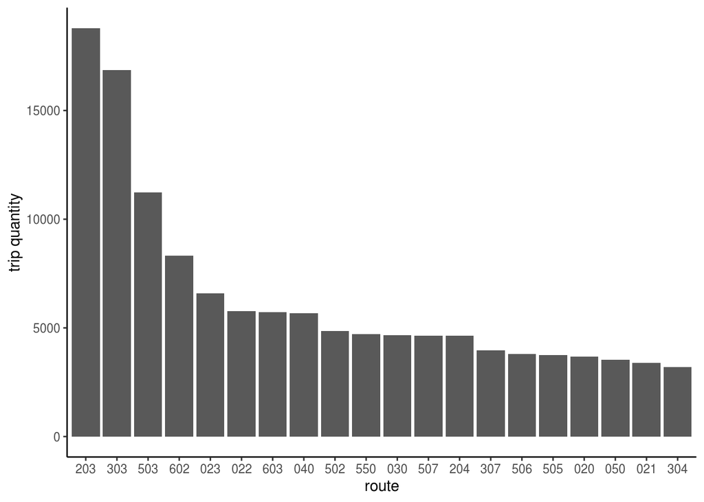

```r
grouped_result %>%
  filter(lubridate::month(lubridate::date(lubridate::ymd(date))) == 7) %>%
  group_by(route) %>%
  summarise(quantity = sum(quantity_trips)) %>%
  top_n(20) %>%
  ggplot(aes(x = reorder(route, -quantity), y = quantity)) + labs(x = "route", y = "trip quantity") + geom_bar(stat = "identity") + theme_classic()
```

5. Quais as rotas menos populares, ou seja, aquelas com menos viagens (levando em consideração o passageiro) durante todo o dia?

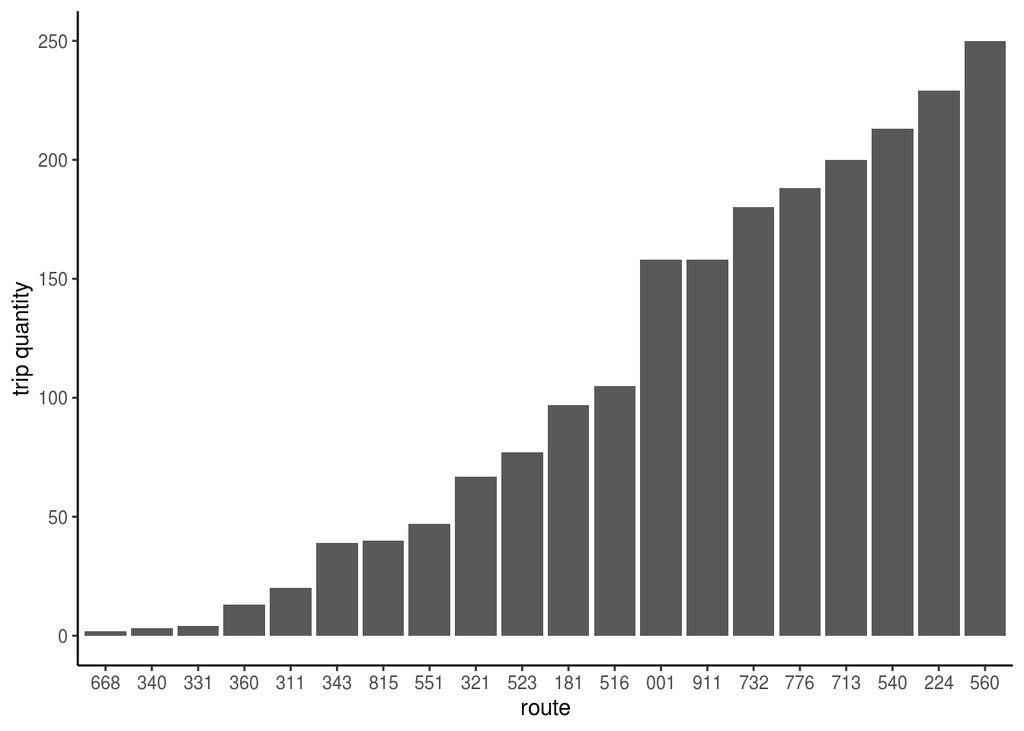

```r
grouped_result %>%
  group_by(route) %>%
  summarise(quantity = sum(quantity_trips)) %>%
  top_n(-20) %>%
  ggplot(aes(x = reorder(route, quantity), y = quantity)) +
    labs(x = "route", y = "trip quantity") +
    geom_bar(stat = "identity") +
    theme_classic()
```

Como destaque temos a rota 732, onde nos dias de segunda e sexta apresenta 56% menos viagens do que nos dias de terça a quinta para os mesmos meses. Taxa bastante significativa. A rota 911 também se destaca, pois a mesma apresenta um aumento no número de viagens de 61% nos dias de terça a quinta em comparação com os dias de segunda e sexta.

Destaque: 732, 911

5.1) Mês a mês temos:

maio:

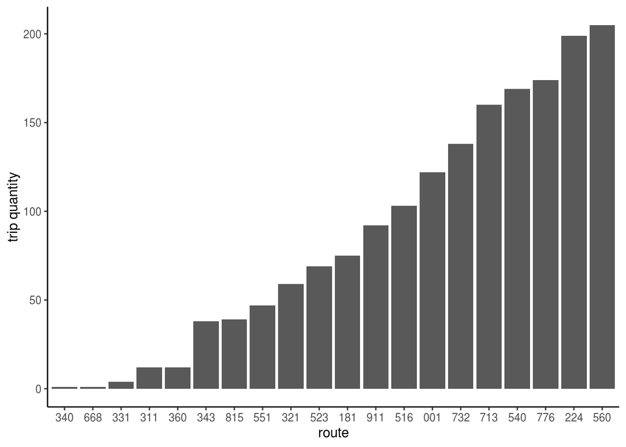

```r
grouped_result %>%
  filter(lubridate::month(lubridate::date(lubridate::ymd(date))) == 5) %>%
  group_by(route) %>%
  summarise(quantity = sum(quantity_trips)) %>%
  top_n(-20) %>%
  ggplot(aes(x = reorder(route, quantity), y = quantity)) + labs(x = "route", y = "trip quantity") + geom_bar(stat = "identity") + theme_classic()
```

junho:

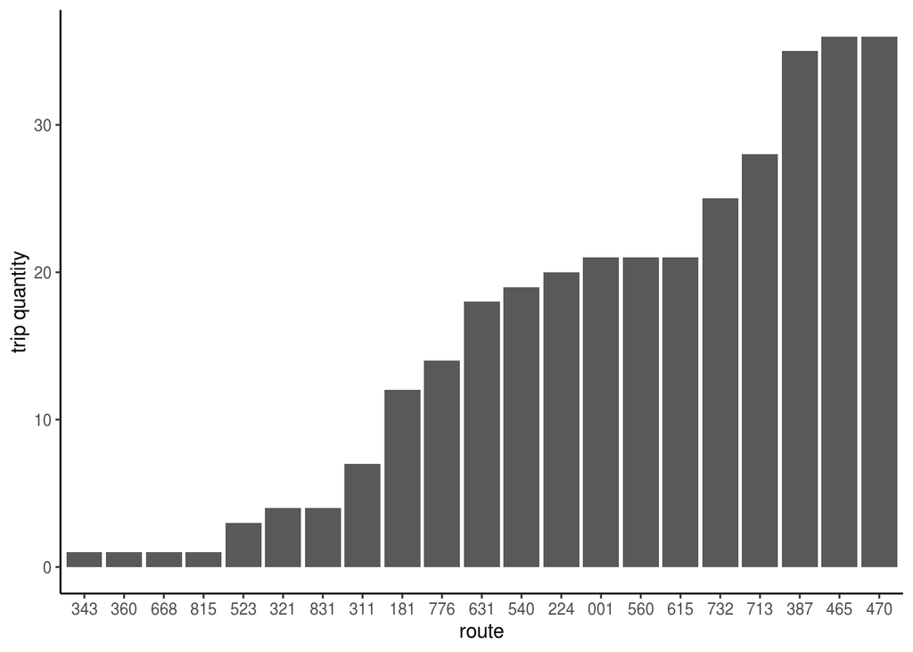

```r
grouped_result %>%
  filter(lubridate::month(lubridate::date(lubridate::ymd(date))) == 6) %>%
  group_by(route) %>%
  summarise(quantity = sum(quantity_trips)) %>%
  top_n(-20) %>%
  ggplot(aes(x = reorder(route, quantity), y = quantity)) + labs(x = "route", y = "trip quantity") + geom_bar(stat = "identity") + theme_classic()
```

julho:

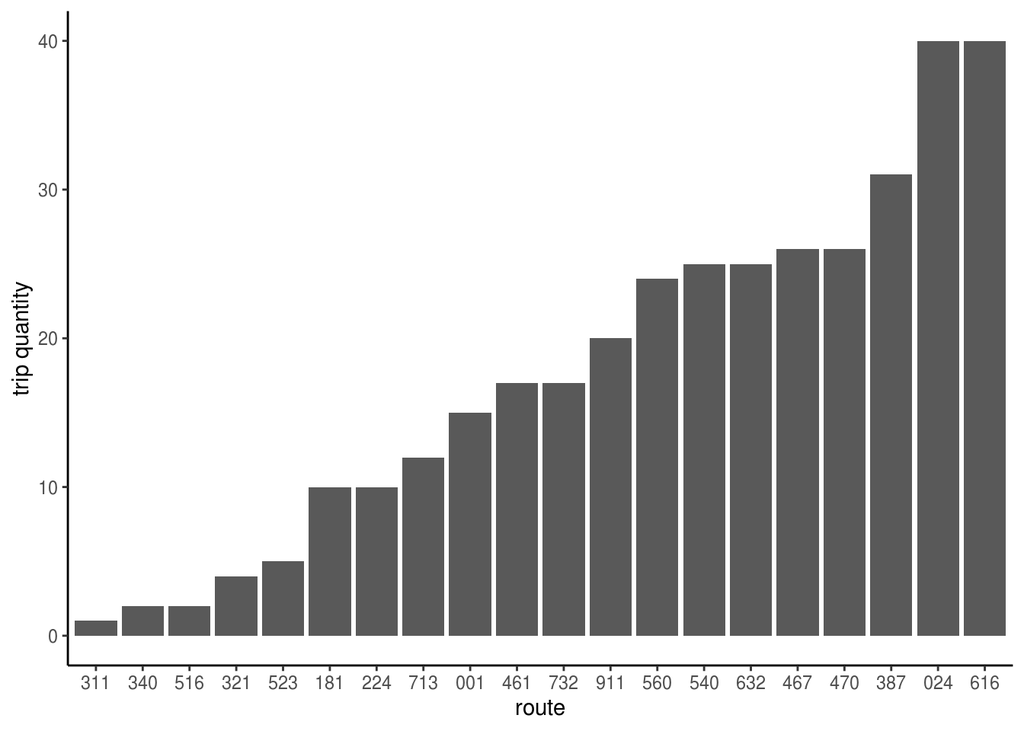

```r
grouped_result %>%
  filter(lubridate::month(lubridate::date(lubridate::ymd(date))) == 7) %>%
  group_by(route) %>%
  summarise(quantity = sum(quantity_trips)) %>%
  top_n(-20) %>%
  ggplot(aes(x = reorder(route, quantity), y = quantity)) + labs(x = "route", y = "trip quantity") + geom_bar(stat = "identity") + theme_classic()
```

6. Quais as rotas cujas viagens são mais demoradas na mediana?

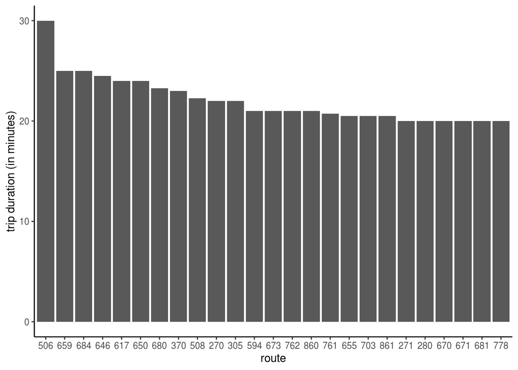

```r
grouped_result %>%
  group_by(route) %>%
  summarise(duration = median(duration_median)) %>%
  top_n(20) %>%
  ggplot(aes(x = reorder(route, -duration), y = duration)) +
    labs(x = "route", y = "trip duration (in minutes)") +
    geom_bar(stat = "identity") +
    theme_classic()
```

7. Quais as rotas cujas viagens são mais rápidas na mediana?

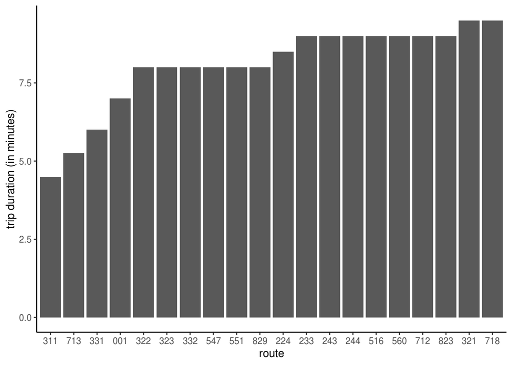

```r
grouped_result %>%
  group_by(route) %>%
  summarise(duration = median(duration_median)) %>%
  top_n(-20) %>%
  ggplot(aes(x = reorder(route, duration), y = duration)) +
    labs(x = "route", y = "trip duration (in minutes)") +
    geom_bar(stat = "identity") +
    theme_classic()
```

Destaque para a rota 322 em compração com segunda e sexta. De terças a quintas a rota apresenta um tempo mediano de 8 minutos enquanto que de segundas e sextas o tempo é de 10 minutos. Uma diferença de 2 minutos, na mediana, para cada viagem, é um tempo significativo.

8. Quais as rotas mais populares (lotadas) das 6h as 8h?

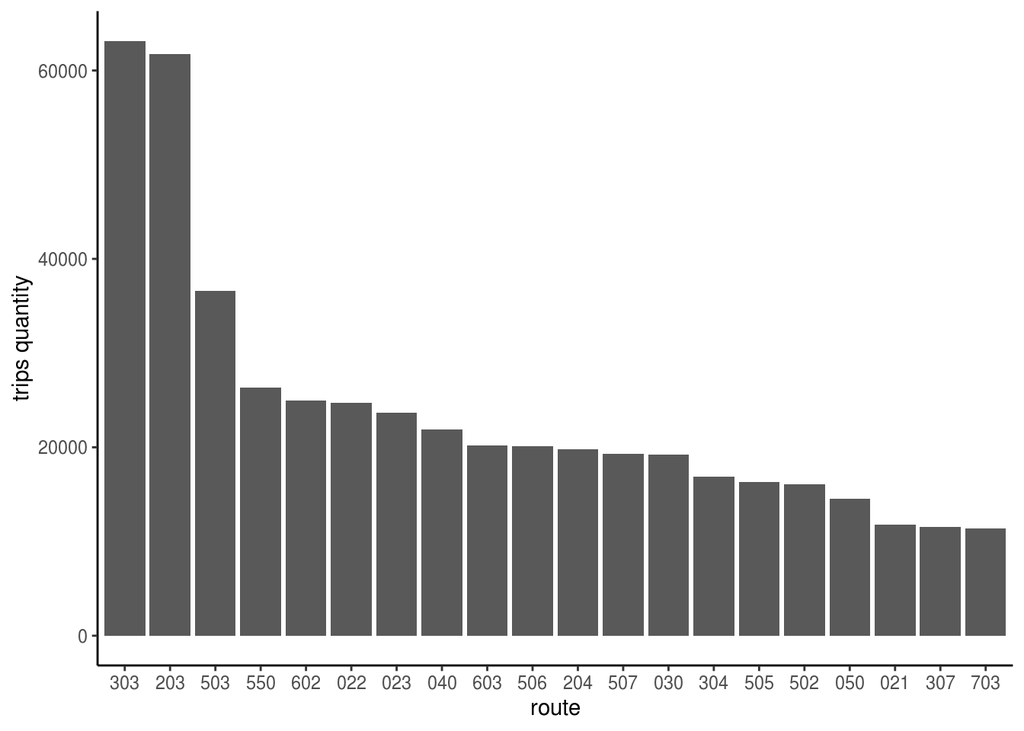

```r
grouped_result %>%
  group_by(route) %>%
  filter(start_hour >= 6 & start_hour <= 8) %>%
  summarise(quantity = sum(quantity_trips)) %>%
  top_n(20) %>%
  ggplot(aes(x = reorder(route, -quantity), y = quantity)) +
    labs(x = "route", y = "trips quantity") +
    geom_col() +
    theme_classic()
```

Comparando com os resultados obtidos na análise de seguna e sexta, temos 3 rotas se destacando. São elas a 022, 204 e a 307. A rota 022 apresenta uma aumento de 43% no número de viagens da segunda e sexta em compração com terça a quinta. Para as rotas 204 e 307 o aumento é de 49% e 41%, respectivamente.

Destaque: 022, 204, 307.

9. Quais as rotas mais populares (lotadas) das 11h as 13h?

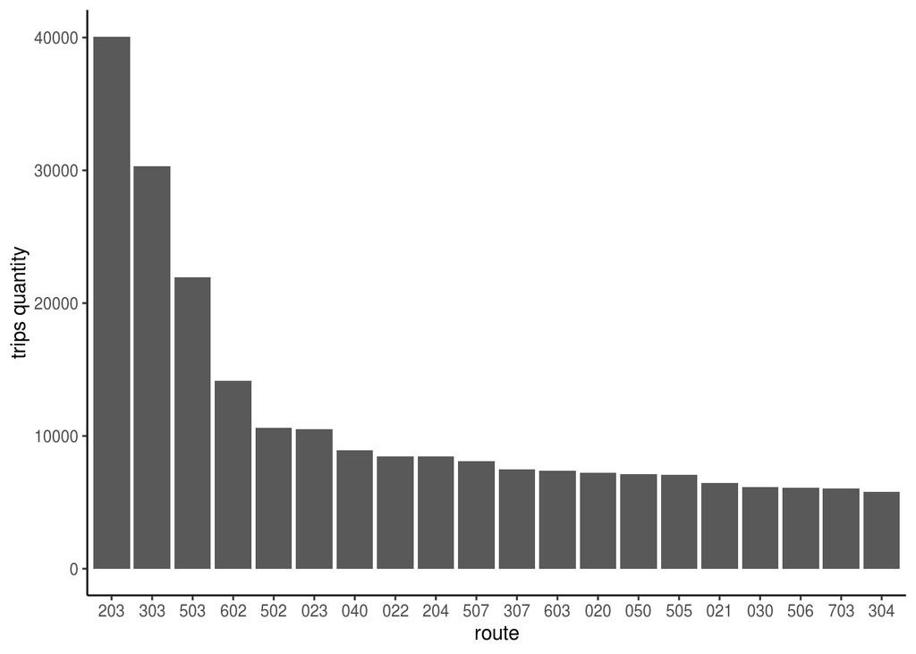

```r
grouped_result %>%
  group_by(route) %>%
  filter(start_hour >= 11 & start_hour <= 13) %>%
  summarise(quantity = sum(quantity_trips)) %>%
  top_n(20) %>%
  ggplot(aes(x = reorder(route, -quantity), y = quantity)) +
    labs(x = "route", y = "trips quantity") +
    geom_col() +
    theme_classic()
```

Comparando também com os resultados obtidos na análise de seguna e sexta, temos agora 2 rotas se destacando. São elas a 502 e a 703. A rota 502 apresenta uma aumento de 51% no número de viagens da segunda e sexta em compração com terça a quinta. Para a 703 o aumento é de 61%.

Destaque: 502, 703.

10. Quais as rotas mais populares (lotadas) das 17h as 19h?

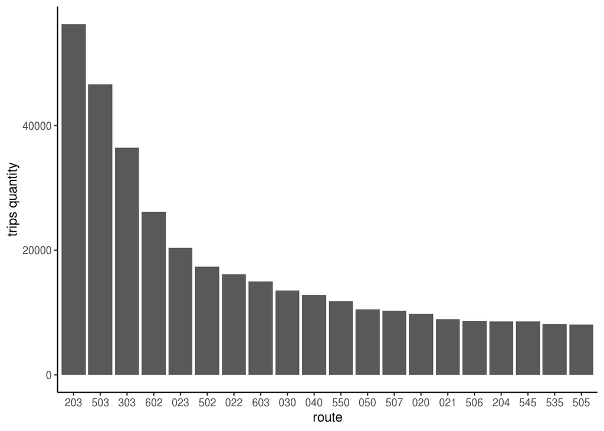

```r
grouped_result %>%
  group_by(route) %>%
  filter(start_hour >= 17 & start_hour <= 19) %>%
  summarise(quantity = sum(quantity_trips)) %>%
  top_n(20) %>%
  ggplot(aes(x = reorder(route, -quantity), y = quantity)) +
    labs(x = "route", y = "trips quantity") +
    geom_col() +
    theme_classic()
```

Destaque: 050, 545, 307.

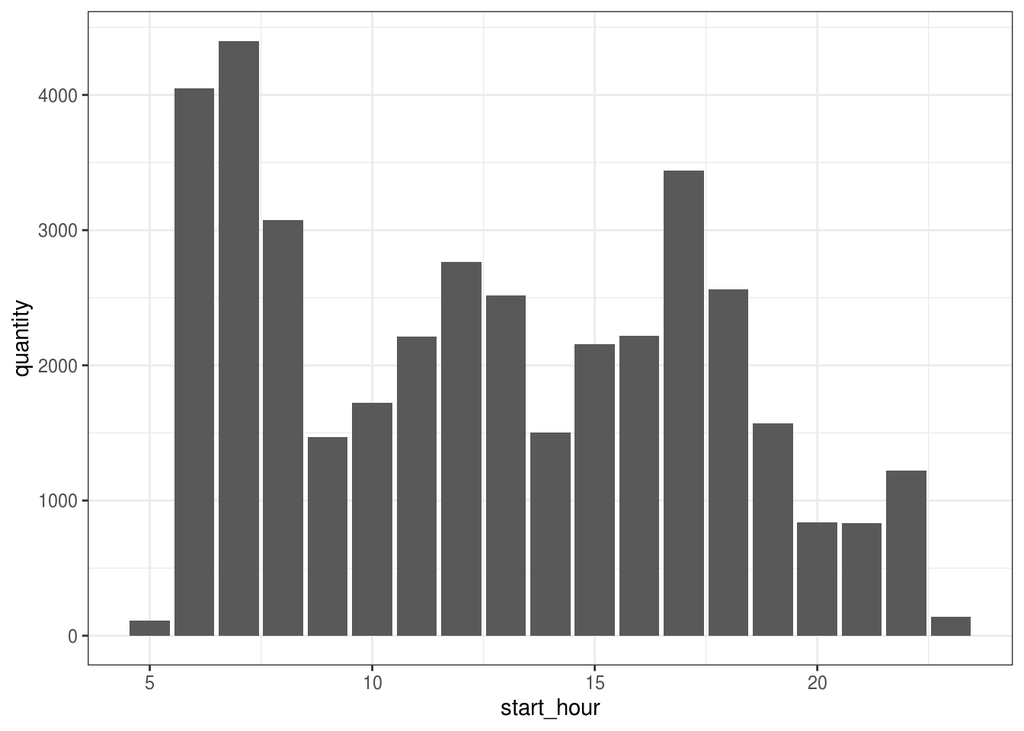

```r
grouped_result %>%
  filter(route == "307") %>%
  group_by(start_hour) %>%
  summarise(quantity = sum(quantity_trips)) %>%
  ggplot(aes(x = start_hour, y = quantity)) + geom_col() + theme_bw()
```

11. A rota 204 apresenta comportamento interessante. Na faixa de horário das 17h as 18h a mesma apresenta uma quantidade de viagens 57% menor do que na faixa de horário das 6h as 8h. Vamos ver a distribuição da quantidade de viagens da rota ao longo de todo o dia.

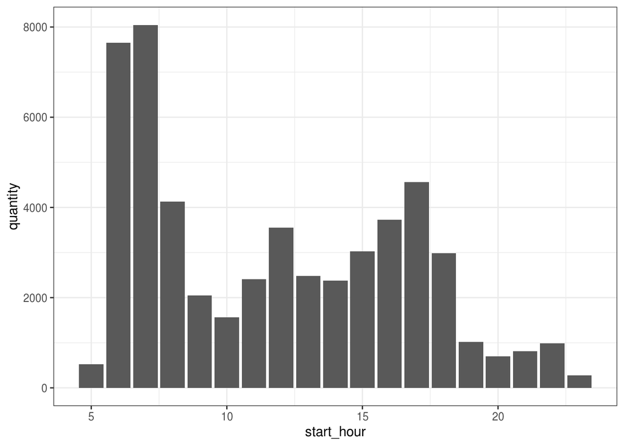

```r
grouped_result %>%
  filter(route == "204") %>%
  group_by(start_hour) %>%
  summarise(quantity = sum(quantity_trips)) %>%
  ggplot(aes(x = start_hour, y = quantity)) + geom_col() + theme_bw()
```

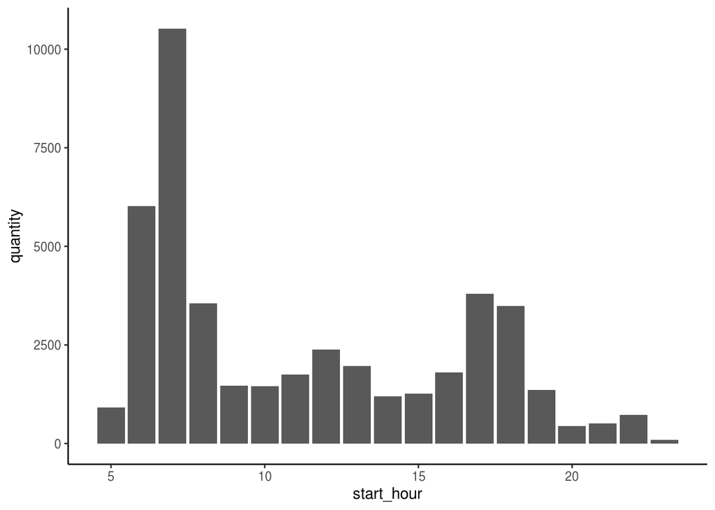

```r
grouped_result %>%
  filter(route == "506") %>%
  group_by(start_hour) %>%
  summarise(quantity = sum(quantity_trips)) %>%
  ggplot(aes(x = start_hour, y = quantity)) + geom_col() + theme_classic()
```

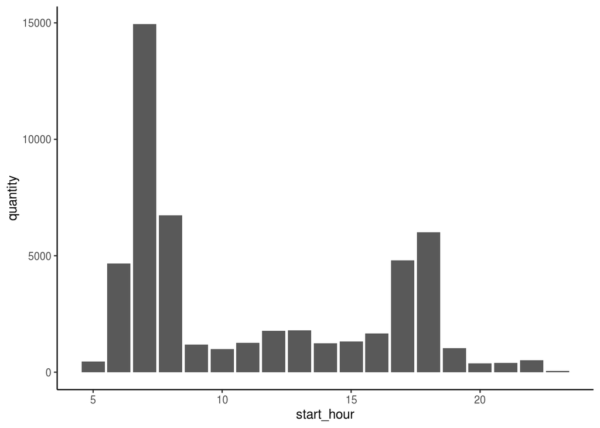

```r
grouped_result %>%
  filter(route == "550") %>%
  group_by(start_hour) %>%
  summarise(quantity = sum(quantity_trips)) %>%
  ggplot(aes(x = start_hour, y = quantity)) + geom_col() + theme_classic()
```